# Crime analysis

### Introduction

This project is made for purpose of Data mining course - Mathematics and Computer science department  
Original data from Kaggle: https://www.kaggle.com/adamschroeder/crimes-new-york-city/version/1  
Data : New York crime data  
Objective : extraction of knowledge related to crimes from dataset  
General purpose of this project is not classic classification of regression problems, but finding out important features of crime nature in New York.

### R Libraries

```r
library(dplyr)
```

```r
library(ggplot2)
library(DT)
library(arules)
library(viridis)
library(viridisLite)
```

### Data

```r
crimeData = read.table("CrimeData.csv",header = TRUE,sep = ',')
crimeData[sample(x = 1:1048575,size = 15),] # a brief look at the data
```

|  | day | month | year | time | Borough | dayPart | Latitude | Longitude | offenseDescription | pdDescription | crimeCompleted | offenseLevel | occurenceLocation | premiseDescription |
| --- | --- | --- | --- | --- | --- | --- | --- | --- | --- | --- | --- | --- | --- | --- |
| 178473 | 19 | 8 | 2015 | 21.00 | MANHATTAN | 17-22 | 40.80418 | -73.96670 | VEHICLE_AND_TRAFFIC_LAWS | LEAVING_SCENE_ACCIDENT_PERSONA | COMPLETED | MISDEMEANOR | MISSING_VALUE | STREET |
| 57141 | 16 | 11 | 2015 | 9.25 | MANHATTAN | 06-12 | 40.73536 | -73.98992 | GRAND_LARCENY | LARCENY_GRAND_FROM_PERSON_PICK | COMPLETED | FELONY | MISSING_VALUE | STREET |
| 204568 | 2 | 8 | 2015 | 0.00 | MANHATTAN | 22-06 | 40.81301 | -73.95655 | ASSAULT_AND_RELATED_OFFENSES | ASSAULT | COMPLETED | MISDEMEANOR | OPPOSITE_OF | RESIDENCE_PUBLIC_HOUSING |
| 21459 | 13 | 12 | 2015 | 18.00 | MANHATTAN | 17-22 | 40.72072 | -73.98131 | CRIMINAL_MISCHIEF_AND_RELATED_OF | MISCHIEF_CRIMINAL___OF_MOTOR | COMPLETED | MISDEMEANOR | MISSING_VALUE | STREET |
| 511296 | 2 | 12 | 2014 | 18.00 | QUEENS | 17-22 | 40.78274 | -73.81883 | PETIT_LARCENY | LARCENY_PETIT_FROM_BUILDING_UN | COMPLETED | MISDEMEANOR | INSIDE | RESIDENCE_HOUSE |
| 383785 | 24 | 3 | 2015 | 9.50 | QUEENS | 06-12 | 40.76454 | -73.89031 | HARRASSMENT_ | HARASSMENT_SUBD___5 | COMPLETED | VIOLATION | INSIDE | RESIDENCE_HOUSE |
| 893286 | 3 | 3 | 2014 | 14.67 | BROOKLYN | 12-17 | NA | NA | ASSAULT_AND_RELATED_OFFENSES | ASSAULT | COMPLETED | MISDEMEANOR | MISSING_VALUE | RESIDENCE_APT_HOUSE |
| 597501 | 29 | 9 | 2014 | 18.00 | BROOKLYN | 17-22 | 40.68675 | -73.94604 | FELONY_ASSAULT | ASSAULT_UNCLASSIFIED | COMPLETED | FELONY | INSIDE | RESIDENCE_PUBLIC_HOUSING |
| 446098 | 26 | 1 | 2015 | 9.00 | QUEENS | 06-12 | 40.76917 | -73.91913 | CRIMINAL_MISCHIEF_AND_RELATED_OF | CRIMINAL_MISCHIEF__TH_GRAFFIT | COMPLETED | MISDEMEANOR | REAR_OF | RESIDENCE_APT_HOUSE |
| 575589 | 15 | 10 | 2014 | 1.38 | BROOKLYN | 22-06 | 40.69678 | -73.94656 | OFF_AGNST_PUB_ORD_SENSBLTY_AND | AGGRAVATED_HARASSMENT_ | COMPLETED | MISDEMEANOR | INSIDE | RESIDENCE_PUBLIC_HOUSING |

[output cut: 5 more lines]

There is a difference beetwen this data and original from Kaggle.  
Simple preprocessing is made and some variables(date event was reported,police jurisdiction…) are ejected, some are changed(date variable to month, day and year, hours and minutes to time…) and some are added(dayPart) due to simplicity. Variables “hours” and “minutes” are joined into 1 continuous variable time - for instance: 15h 30min is now 15.5 (15 + 30/60).  
Variable “time” is divided into categorical variable “dayPart” with 4 classes(parts of the day).  
All NA’s are replaced with “MISSING_VALUE”

```r
summary(crimeData)
```

```
##       day            month             year           time
##  Min.   : 1.00   Min.   : 1.000   Min.   :1015   Min.   : 0.00
##  1st Qu.: 8.00   1st Qu.: 4.000   1st Qu.:2014   1st Qu.: 9.00
##  Median :15.00   Median : 7.000   Median :2014   Median :14.67
##  Mean   :15.52   Mean   : 6.947   Mean   :2014   Mean   :13.51
##  3rd Qu.:23.00   3rd Qu.:10.000   3rd Qu.:2015   3rd Qu.:19.00
##  Max.   :31.00   Max.   :12.000   Max.   :2015   Max.   :23.98
##  NA's   :65      NA's   :65       NA's   :65
##    Borough            dayPart             Latitude       Longitude
##  Length:1048575     Length:1048575     Min.   :40.50   Min.   :-74.26
##  Class :character   Class :character   1st Qu.:40.67   1st Qu.:-73.97
##  Mode  :character   Mode  :character   Median :40.73   Median :-73.93
##                                        Mean   :40.73   Mean   :-73.93
##                                        3rd Qu.:40.81   3rd Qu.:-73.88
##                                        Max.   :40.91   Max.   :-73.70
##                                        NA's   :32417   NA's   :32417
##  offenseDescription pdDescription      crimeCompleted     offenseLevel
##  Length:1048575     Length:1048575     Length:1048575     Length:1048575
##  Class :character   Class :character   Class :character   Class :character
##  Mode  :character   Mode  :character   Mode  :character   Mode  :character
##
##
##
##
##  occurenceLocation  premiseDescription
##  Length:1048575     Length:1048575
##  Class :character   Class :character
##  Mode  :character   Mode  :character
##
##
##
##
```

### Data visualization

The most crimes generally occur in Brooklyn while least number of crimes occur in Staten Island

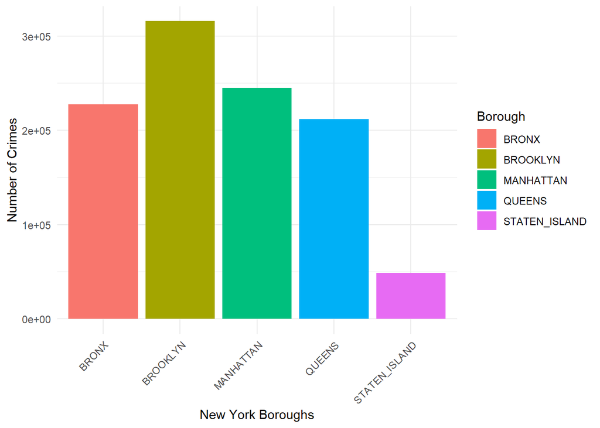

```r
ggplot(data = crimeData) +
  geom_bar(mapping = aes(x = Borough, fill = Borough)) +
  xlab("New York Boroughs") + ylab("Number of Crimes") +
  theme_minimal() +
  theme(axis.text.x = element_text(angle = 45, hjust = 1))
```

Distribution of “offense level” variable  
Misdemeanor offense dominate over felony and violation.

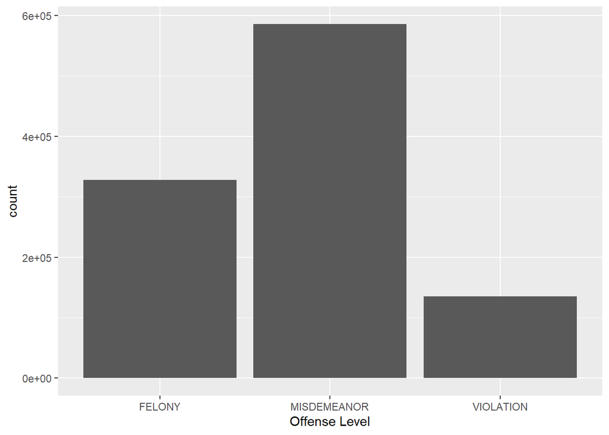

```r
ggplot(data = crimeData) +
  geom_bar(mapping = aes(x = offenseLevel)) +
  xlab("Offense Level")
```

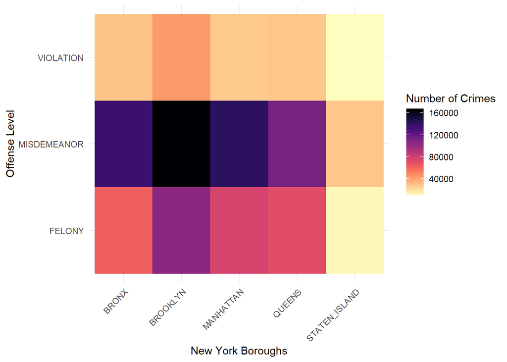

```r
subset(crimeData, year >= 2012) %>%
  count(Borough, offenseLevel) %>%
  ggplot(mapping = aes(x = Borough, y = offenseLevel, fill = n)) +
  geom_tile() +
  labs(x = "New York Boroughs", y = "Offense Level", fill = "Number of Crimes") +
  scale_fill_viridis(option = "A", direction = -1) +
  theme_minimal() +
  theme(axis.text.x = element_text(angle = 45, hjust = 1)) +
  theme(legend.position = "right")
```

Distribution of each offense level through the day.  
It is clear that second part of the day (17-21) is the time when most crimes of each level occur and the morning is the part of the day with less crime appearances.

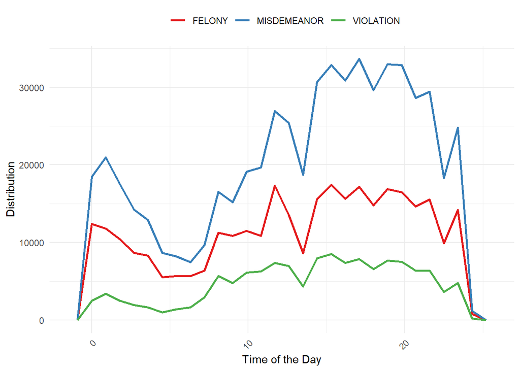

```r
options(repr.plot.width = 12, repr.plot.height = 5)
ggplot(crimeData, mapping = aes(x = time, colour = offenseLevel)) +
  geom_freqpoly(binwidth = 0.9, lwd = 1) +
  xlab("Time of the Day") +
  ylab("Distribution") +
  theme_minimal() +
  scale_color_brewer(palette = "Set1") +
  theme(legend.position = "top",
        legend.title = element_blank(),
        axis.text.x = element_text(angle = 45, hjust = 1))
```

This trend don’t change over time.  
The similar pattern occur if one smaller subset(44% of data) of data is taken (only crimes from last year - 2015)

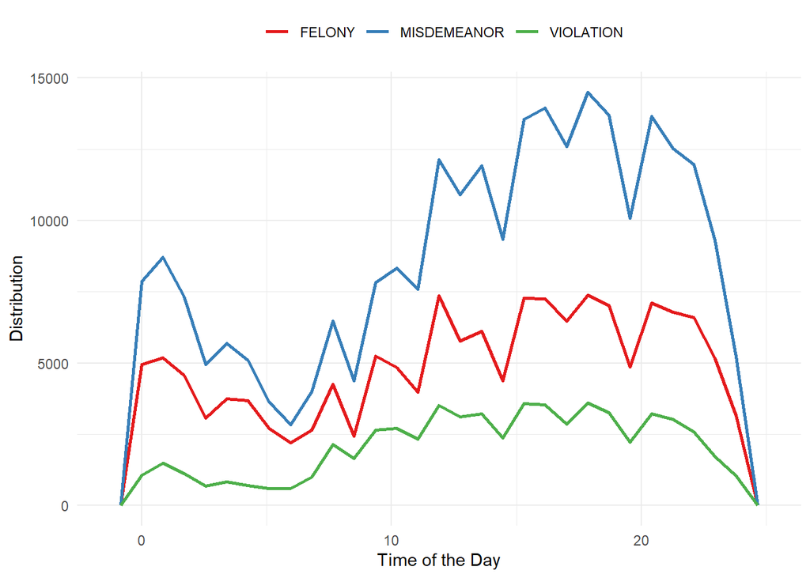

```r
options(repr.plot.width=9, repr.plot.height=5)
subset(crimeData, year == 2015) %>%
  ggplot(mapping = aes(x = time, colour = offenseLevel)) +
  geom_freqpoly(binwidth = 0.85, lwd = 1) +
  xlab("Time of the Day") + ylab("Distribution") +
  theme_minimal() +
  theme(legend.position = "top", legend.title = element_blank()) +
  scale_color_brewer(palette = "Set1")
```

2014 year

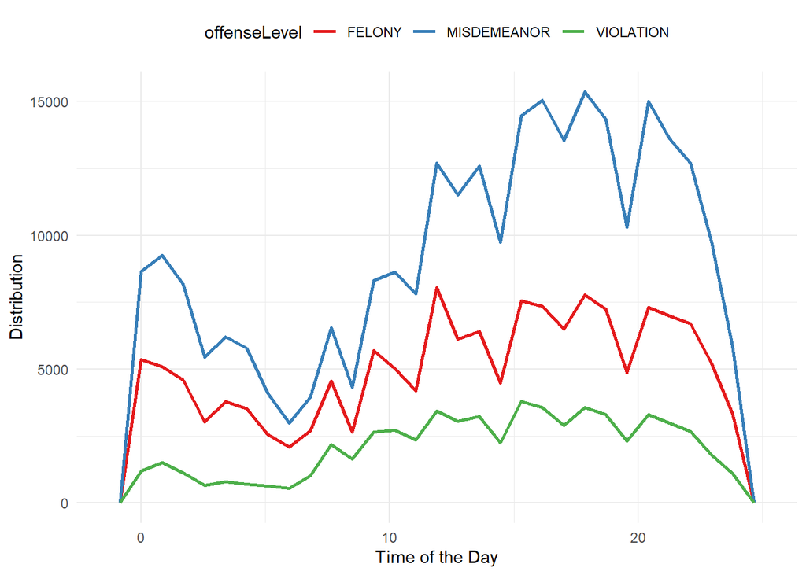

```r
options(repr.plot.width=9, repr.plot.height=5)
subset(crimeData, year == 2014) %>%
  ggplot(mapping = aes(x = time, colour = offenseLevel)) +
  geom_freqpoly(binwidth = 0.85, lwd = 1) +
  xlab("Time of the Day") + ylab("Distribution") +
  theme_minimal() +
  theme(legend.position = "top") +
  scale_color_brewer(palette = "Set1")
```

Relation beetwen New York boroughs, offense level and time.  
Crime offense levels mostly don’t depend on borough but on time od the day.

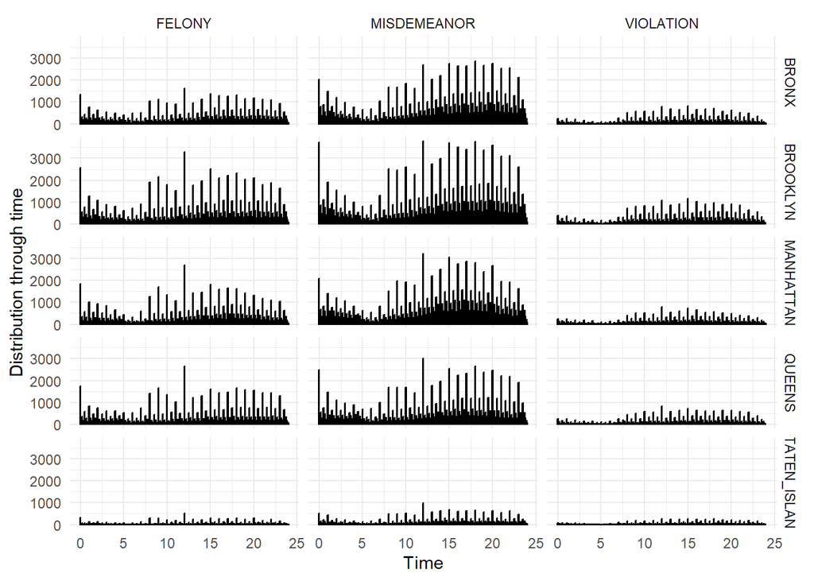

```r
options(repr.plot.width=10, repr.plot.height=7)
ggplot(data = subset(crimeData, year >= 2012), aes(x = time)) +
  geom_histogram(binwidth = 0.1, color = "black", fill = "blue", alpha = 0.6) +
  facet_grid(Borough ~ offenseLevel) +
  labs(x = "Time", y = "Distribution through time") +
  theme_minimal() +
  theme(legend.position = "bottom")
```

Offense level vs. crime location  
Inside crimes are dominant independently of crime level.

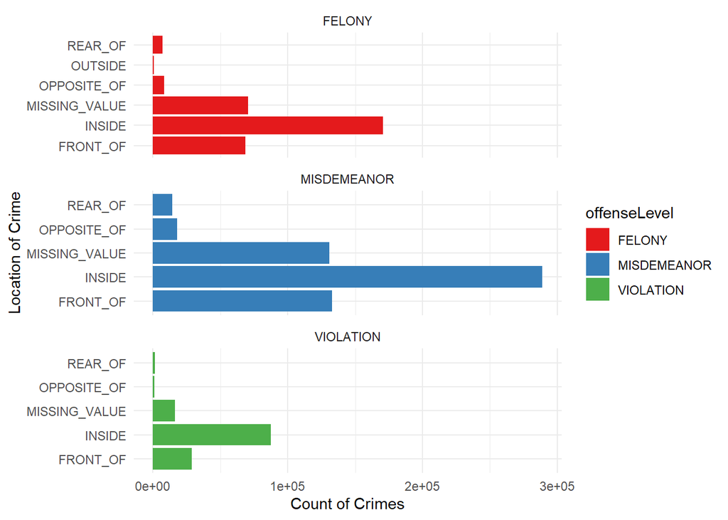

```r
ggplot(data = subset(crimeData, year >= 2013), aes(x = occurenceLocation)) +
  geom_bar(aes(fill = offenseLevel), position = "dodge") +
  labs(x = "Location of Crime", y = "Count of Crimes") +
  facet_wrap(~offenseLevel, ncol = 1, scales = "free_y") +
  coord_flip() +
  theme_minimal() +
  scale_fill_brewer(palette = "Set1")
```

### How to get some new information - simple example

One of the main tasks of data mining is extraction new data and information from the old one. Here is a very simple example of getting day of the week from a given date.

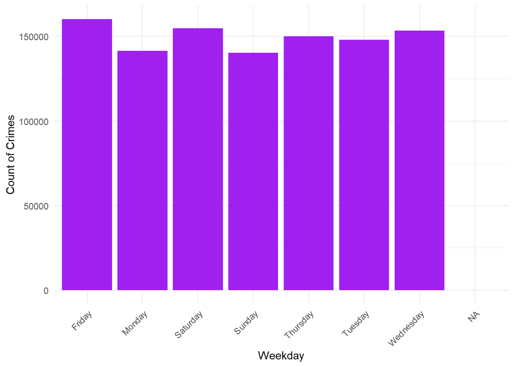

```r
crimeData[15] <- crimeData[, c(3, 2, 1)] %>%
  apply(MARGIN = 1, FUN = function(vec) {paste(vec, collapse = '-')}) %>%
  as.Date() %>%
  weekdays()

names(crimeData)[15] <- 'weekDay'
options(repr.plot.width = 7, repr.plot.height = 5)
ggplot(data = crimeData, aes(x = weekDay)) +
  geom_bar(fill = "purple") +
  xlab("Weekday") + ylab("Count of Crimes") +
  theme_minimal() +
  theme(axis.text.x = element_text(angle = 45, hjust = 1))
```

### Day of the week vs. time (year 2014 and 2015)

As it can be seen, the most dangerous time of the week is weekend night(saturday and sunday 22-06) and middle of the week through the day, while the less dangerous is the middle of the week at night and weekend mornings. For this and similar analysis, the idea is to track new trends that might happen and for that reason newer data should be taken for analysis(in this case last 2 years).

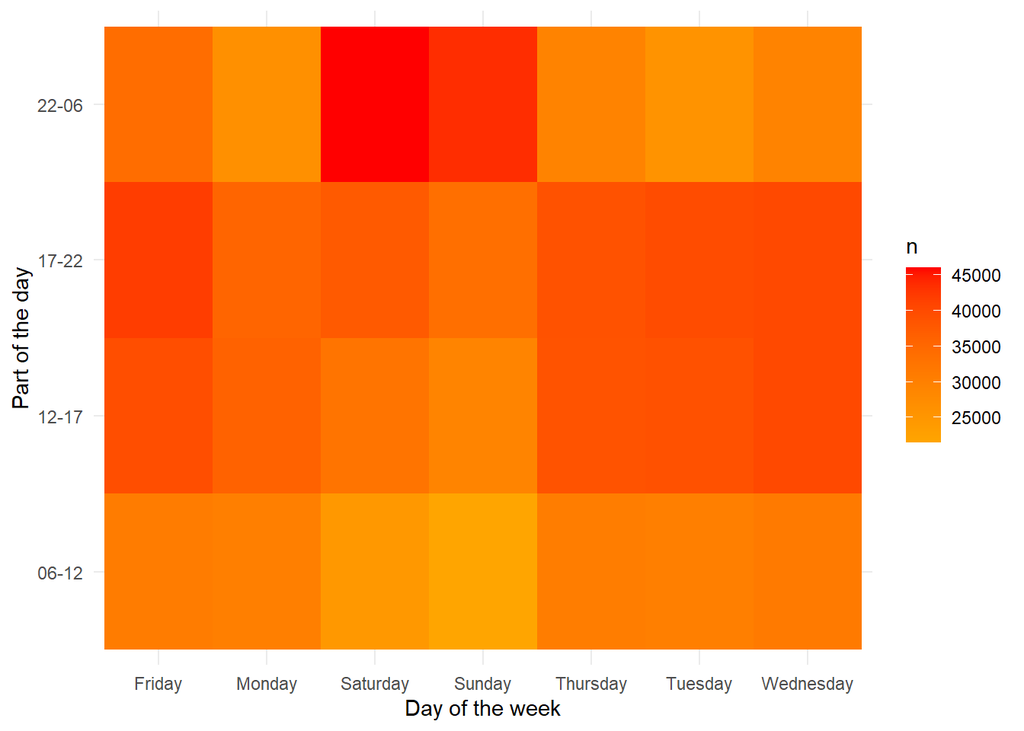

```r
subset(crimeData, !is.na(weekDay) & year >= 2014) %>%
  count(weekDay, dayPart) %>%
  ggplot(mapping = aes(x = weekDay, y = dayPart)) +
  geom_tile(mapping = aes(fill = n)) +
  xlab("Day of the week") + ylab("Part of the day") +
  theme_minimal() +
  scale_fill_gradient(low = "orange", high = "red")
```

### Some things happen more often than the others - interactive data tables

```
## You can override using the `.groups` argument.
```

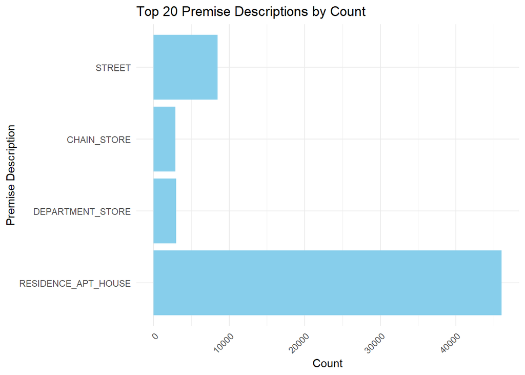

```r
subset(crimeData, year >= 2014 & occurenceLocation != "MISSING_VALUE") %>%
  group_by(offenseDescription, Borough, dayPart, premiseDescription) %>%
  summarize(count = n()) %>%
  arrange(desc(count)) %>%
  head(20) %>%
  ggplot(mapping = aes(x = reorder(premiseDescription, -count), y = count)) +
  geom_bar(stat = "identity", fill = "skyblue") +  # Change the fill color
  xlab("Premise Description") + ylab("Count") +
  ggtitle("Top 20 Premise Descriptions by Count") +
  theme_minimal() +
  theme(axis.text.x = element_text(angle = 45, hjust = 1)) +
  coord_flip()
```

```r
summary_data <- subset(crimeData, year >= 2014 & occurenceLocation != "MISSING_VALUE") %>%
  group_by(occurenceLocation, Borough, dayPart, pdDescription) %>%
  summarize(count = n()) %>%
  arrange(desc(count)) %>%
  head(20)
```

```
## You can override using the `.groups` argument.
```

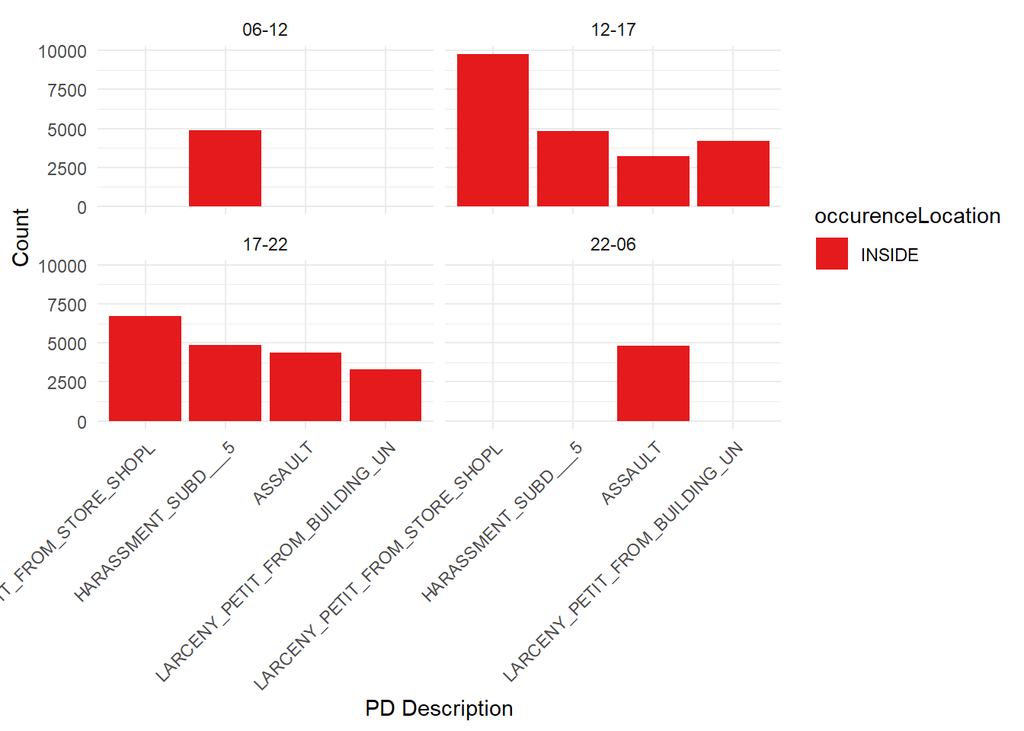

```r
ggplot(summary_data, aes(x = reorder(pdDescription, -count), y = count, fill = occurenceLocation)) +
  geom_bar(stat = "identity", position = "dodge") +
  facet_wrap(~dayPart) +
  labs(x = "PD Description", y = "Count") +
  theme_minimal() +
  theme(axis.text.x = element_text(angle = 45, hjust = 1)) +
  scale_fill_brewer(palette = "Set1")
```

### Felony

2015 felony related crimes - small pattern emerges.  
The most dangerous place for this specific category is Brooklyn - 12 h, at beginning of the week. The same pattern come up for 2014 year.

```r
subset(crimeData,year == 2015 & offenseLevel == "FELONY") %>% group_by(Borough,time,weekDay) %>% summarise(count = n()) %>%
arrange(desc(count)) %>% head(30) %>% datatable(options = list(pageLength = 10,scrollX='400px'))
```

|  | Borough | time | weekDay | count |
| --- | --- | --- | --- | --- |
| 1 | BROOKLYN | 12 | Monday | 228 |
| 2 | BROOKLYN | 12 | Friday | 217 |
| 3 | BROOKLYN | 12 | Tuesday | 214 |
| 4 | BROOKLYN | 15 | Friday | 199 |
| 5 | BROOKLYN | 12 | Thursday | 192 |
| 6 | BROOKLYN | 12 | Wednesday | 190 |
| 7 | QUEENS | 12 | Monday | 179 |
| 8 | MANHATTAN | 12 | Friday | 177 |
| 9 | MANHATTAN | 12 | Thursday | 173 |
| 10 | BROOKLYN | 17 | Friday | 172 |

[output cut: 20 more lines]

## Association rules

Association rules are rule-based data mining method for discovering certain relations between variables in data-sets. The main purpose of association rules is to discover strong rules in data-sets using measures of interestingness.  
Let $I=\{i_1,...,i_n\}$ be the set of variables in the dataset. Observations of data-set (rows of data frame) are usually called **transactions**. A rule is defined like implication $A \implies B$ where $A,B \subset I$.  
$A$ is usually called antecedent or left-hand-side (LHS) and $Y$ consequent or right-hand-side (RHS). In some implementations rule is defined like $A \implies i_j$ where $i_j \in I$.

### Significant measures

Let $X,Y$ be itemsets, $X \implies Y$ an association rule and $T$ a set of transactions of a given data-set.

### Support

Support is an indication of how frequently the itemset appears in the dataset.  
It is proportion of transactions(rows in data frame) that contain specific itemset, with respect to number of transactions.  
$supp(X) = \frac{|t \in T ; X \subset t|}{|T|}$

### Confidence

Confidence is an indication of how often the rule has been found to be true.  
$conf(X \cup Y) = \frac{supp(X \cup Y)}{supp(X)}$  
Confidence can be interpreted as an estimate of the conditional probability $P(Y|X)$, the probability of finding the $Y$ in transactions under the condition that these transactions also contain the $X$ in the left side of the rule.

### The lift

The lift of a rule is defined as $lift(X \implies Y) = \frac{supp(X \cup Y)}{supp(X) * supp(Y)}$  
It is the ratio of the observed support to that expected if X and Y were independent events.  
If $X$ and $Y$ are truly independent events, we can expect that about $supp(X) * supp(Y)$ number of transactions will contain both of them.  
If the rule had a **lift of 1**, it would imply that the probability of occurrence of the antecedent and that of the consequent are independent of each other. When two events are independent of each other, no rule can be drawn involving those two events.  
If the **lift is > 1**, that lets us know the degree to which those two occurrences are dependent on one another, and makes those rules potentially useful for predicting the consequent in future data sets.  
If the **lift is < 1**, that lets us know the items are substitute to each other. This means that presence of one item has negative effect on presence of other item and vice versa.  
Definitons taken from : https://en.wikipedia.org/wiki/Association_rule_learning  
R implementation: library arules , apriori algorithm.

### Example - wrong way of using association rules

One of the obvious wrong ways of using of association rules is to apply it to variables that are obviously correlated in some way. In this dataset for instance we could get rule like:  
offenseDescription = ASSAULT_AND_RELATED_OFFENSES $\implies$ pdDescription = ASSAULT. It is clear and natural that these 2 variables are in close relationship, so although this rule might have large lift, is not very helpfull. For this reason in examples below algorithm will take only some subset of variables, excluding others that are obviously correlated with them.

### Apriori algorithm

Apriori algorithm is classic algorithm for generating association rules from datasets or databases.  
The key idea of the algorithm is to begin by generating frequent itemsets with just one item (1-itemsets) and to recursively generate frequent itemsets with 2 items, then frequent 3-itemsets and so on till some stopping condition is satisfied.  
This is where computational complexity comes into the game.  
Apriori algorithm is based on very simple observation: **subsets of frequent itemsets are also frequent itemsets**. In other words , if some itemset is proven to be non-frequent , then it will not be considered by algorithm any more for forming new frequent itemsets. To identify the k-itemsets that are not frequent algorithm need to examine all subsets of size (k-1) of each candidate k-itemset.  
It generates candidate itemsets of length k from item sets of length k-1. Then it prunes the candidates which have an infrequent sub-pattern.

```r
rules <- apriori(data = subset(crimeData,year >= 2013)[,-c(1,2,3,6,7,8,9,10,11,14)] ,
parameter = list(support = 0.03 , confidence = 0.6,maxlen = 5,target = 'rules'))
```

```
## Apriori
##
## Parameter specification:
##  confidence minval smax arem  aval originalSupport maxtime support minlen
##         0.6    0.1    1 none FALSE            TRUE       5    0.03      1
##  maxlen target  ext
##       5  rules TRUE
##
## Algorithmic control:
##  filter tree heap memopt load sort verbose
##     0.1 TRUE TRUE  FALSE TRUE    2    TRUE
##
## Absolute minimum support count: 31353
##
## set item appearances ...[0 item(s)] done [0.00s].
## set transactions ...[24 item(s), 1045101 transaction(s)] done [0.23s].
## sorting and recoding items ... [21 item(s)] done [0.03s].
## creating transaction tree ... done [0.94s].
## checking subsets of size 1 2 3 4 done [0.00s].
## writing ... [7 rule(s)] done [0.00s].
## creating S4 object  ... done [0.09s].
```

```r
inspect(sort(rules,by='lift'))
```

```
##     lhs                                  rhs                           support confidence   coverage     lift  count
## [1] {offenseLevel=VIOLATION}          => {occurenceLocation=INSIDE} 0.08360436  0.6466426 0.12928990 1.236093  87375
## [2] {time=[11.3,17.5),
##      Borough=MANHATTAN}               => {occurenceLocation=INSIDE} 0.05160458  0.6279414 0.08218057 1.200345  53932
## [3] {Borough=MANHATTAN,
##      offenseLevel=FELONY}             => {occurenceLocation=INSIDE} 0.04407995  0.6062536 0.07270876 1.158888  46068
## [4] {Borough=BRONX,
##      occurenceLocation=MISSING_VALUE} => {offenseLevel=MISDEMEANOR} 0.03050040  0.6278635 0.04857808 1.122953  31876
## [5] {time=[17.5,24],
##      Borough=BRONX}                   => {offenseLevel=MISDEMEANOR} 0.04869864  0.6273884 0.07762121 1.122103  50895
## [6] {time=[0,11.3),
##      occurenceLocation=MISSING_VALUE} => {offenseLevel=MISDEMEANOR} 0.04490858  0.6237491 0.07199783 1.115594  46934
## [7] {occurenceLocation=MISSING_VALUE} => {offenseLevel=MISDEMEANOR} 0.12501663  0.6005801 0.20815979 1.074156 130655
```

In the example above, the first couple of rules have the lift that is slightly greater than 1 which means there might be light correlation between these itemsets. On the other hand, this might be because value “INSIDE” (1st rule) for occurenceLocation is dominating over the other values of occurenceLocation.  
Intuitive way of interpreting this rule is something like “when crime belongs to the level VIOLATION, it is slightly more likely that it happened INSIDE than then somewhere else”.  
However, confidence of this rule could be somewhat better so we can’t accept that this is strong connection between these 2 variables although lift implies some dependence.

### Trying to detect what is the cause of rare events

```r
rules <- apriori(data = subset(crimeData,year >= 2011)[,c(4,5,9,11,14)] ,
parameter = list(support = 0.000001 , confidence = 0.85,maxlen = 5),
appearance = list(rhs = c('crimeCompleted=ATTEMPTED')))
```

```
## Apriori
##
## Parameter specification:
##  confidence minval smax arem  aval originalSupport maxtime support minlen
##        0.85    0.1    1 none FALSE            TRUE       5   1e-06      1
##  maxlen target  ext
##       5  rules TRUE
##
## Algorithmic control:
##  filter tree heap memopt load sort verbose
##     0.1 TRUE TRUE  FALSE TRUE    2    TRUE
##
## Absolute minimum support count: 1
##
## set item appearances ...[1 item(s)] done [0.00s].
## set transactions ...[150 item(s), 1046908 transaction(s)] done [0.25s].
## sorting and recoding items ... [146 item(s)] done [0.03s].
## creating transaction tree ... done [1.01s].
## checking subsets of size 1 2 3 4 5 done [0.01s].
## writing ... [10 rule(s)] done [0.00s].
## creating S4 object  ... done [0.12s].
```

```r
inspect(head(sort(rules,by='lift'),10))
```

```
##      lhs                                                      rhs                             support confidence     coverage     lift count
## [1]  {offenseDescription=FRAUDULENT_ACCOSTING,
##       premiseDescription=PARKING_LOT_GARAGE_(PUBLIC)}      => {crimeCompleted=ATTEMPTED} 1.910388e-06          1 1.910388e-06 55.93055     2
## [2]  {offenseDescription=RAPE,
##       premiseDescription=BEAUTY_&_NAIL_SALON}              => {crimeCompleted=ATTEMPTED} 1.910388e-06          1 1.910388e-06 55.93055     2
## [3]  {time=[11.3,17.5),
##       offenseDescription=RAPE,
##       premiseDescription=TRANSIT_NYC_SUBWAY}               => {crimeCompleted=ATTEMPTED} 2.865581e-06          1 2.865581e-06 55.93055     3
## [4]  {Borough=STATEN_ISLAND,
##       offenseDescription=BURGLARY,
##       premiseDescription=BANK}                             => {crimeCompleted=ATTEMPTED} 1.910388e-06          1 1.910388e-06 55.93055     2
## [5]  {time=[11.3,17.5),
##       Borough=MANHATTAN,
##       offenseDescription=KIDNAPPING_AND_RELATED_OFFENSES,
##       premiseDescription=STREET}                           => {crimeCompleted=ATTEMPTED} 1.910388e-06          1 1.910388e-06 55.93055     2
## [6]  {time=[0,11.3),
##       Borough=MANHATTAN,
##       offenseDescription=ROBBERY,
##       premiseDescription=BUS_STOP}                         => {crimeCompleted=ATTEMPTED} 1.910388e-06          1 1.910388e-06 55.93055     2
## [7]  {time=[17.5,24],
##       Borough=MANHATTAN,
##       offenseDescription=ROBBERY,
##       premiseDescription=BUS_STOP}                         => {crimeCompleted=ATTEMPTED} 2.865581e-06          1 2.865581e-06 55.93055     3
## [8]  {time=[11.3,17.5),
##       Borough=MANHATTAN,
##       offenseDescription=RAPE,
##       premiseDescription=TRANSIT_NYC_SUBWAY}               => {crimeCompleted=ATTEMPTED} 1.910388e-06          1 1.910388e-06 55.93055     2
## [9]  {time=[0,11.3),
##       Borough=STATEN_ISLAND,
##       offenseDescription=BURGLARY,
##       premiseDescription=BANK}                             => {crimeCompleted=ATTEMPTED} 1.910388e-06          1 1.910388e-06 55.93055     2
## [10] {time=[11.3,17.5),
##       Borough=STATEN_ISLAND,
##       offenseDescription=BURGLARY,
##       premiseDescription=SMALL_MERCHANT}                   => {crimeCompleted=ATTEMPTED} 1.910388e-06          1 1.910388e-06 55.93055     2
```

Greater count implies that we need to sacrifice confidence.  
Left-hand side of these rules with great lift value, contains some specific events like explicit part of the day when “KIDNAPPING_AND_RELATED_OFFENSES” crimes happend on the street.

```r
rules <- apriori(data = subset(crimeData,year >= 2013)[,c(4,5,9,11,14)] ,
parameter = list(support = 0.00001 , confidence = 0.55,maxlen = 5),
appearance = list(rhs = c('crimeCompleted=ATTEMPTED')))
```

```
## Apriori
##
## Parameter specification:
##  confidence minval smax arem  aval originalSupport maxtime support minlen
##        0.55    0.1    1 none FALSE            TRUE       5   1e-05      1
##  maxlen target  ext
##       5  rules TRUE
##
## Algorithmic control:
##  filter tree heap memopt load sort verbose
##     0.1 TRUE TRUE  FALSE TRUE    2    TRUE
##
## Absolute minimum support count: 10
##
## set item appearances ...[1 item(s)] done [0.00s].
## set transactions ...[150 item(s), 1045101 transaction(s)] done [0.27s].
## sorting and recoding items ... [135 item(s)] done [0.03s].
## creating transaction tree ... done [1.02s].
## checking subsets of size 1 2 3 4 5 done [0.01s].
## writing ... [3 rule(s)] done [0.00s].
## creating S4 object  ... done [0.13s].
```

```r
inspect(head(sort(rules,by='lift'),10))
```

```
##     lhs                                                      rhs                             support confidence     coverage     lift count
## [1] {time=[11.3,17.5),
##      offenseDescription=KIDNAPPING_AND_RELATED_OFFENSES,
##      premiseDescription=STREET}                           => {crimeCompleted=ATTEMPTED} 1.435268e-05  0.6521739 2.200744e-05 36.47975    15
## [2] {Borough=BRONX,
##      offenseDescription=ROBBERY,
##      premiseDescription=CHECK_CASHING_BUSINESS}           => {crimeCompleted=ATTEMPTED} 1.339583e-05  0.5833333 2.296429e-05 32.62911    14
## [3] {time=[0,11.3),
##      offenseDescription=ROBBERY,
##      premiseDescription=CHECK_CASHING_BUSINESS}           => {crimeCompleted=ATTEMPTED} 1.913691e-05  0.5555556 3.444643e-05 31.07534    20
```

Association rules allow us to discover nature of serious crimes, like burglary and larceny (for 2015 year).  
Rules with higher lift and confidence are good candidates for better research because they imply that there might be some connection between certain variables in this subset of data.

```r
rules <- apriori(data = subset(crimeData,year == 2015)[,c(4,5,9,11,14,15)] ,
parameter = list(support = 0.00001 , confidence = 0.7,maxlen = 5,target='rules'),
appearance = list(rhs = c('offenseDescription=BURGLARY')))
```

```
## Apriori
##
## Parameter specification:
##  confidence minval smax arem  aval originalSupport maxtime support minlen
##         0.7    0.1    1 none FALSE            TRUE       5   1e-05      1
##  maxlen target  ext
##       5  rules TRUE
##
## Algorithmic control:
##  filter tree heap memopt load sort verbose
##     0.1 TRUE TRUE  FALSE TRUE    2    TRUE
##
## Absolute minimum support count: 4
##
## set item appearances ...[1 item(s)] done [0.00s].
## set transactions ...[154 item(s), 468576 transaction(s)] done [0.12s].
## sorting and recoding items ... [143 item(s)] done [0.02s].
## creating transaction tree ... done [0.40s].
## checking subsets of size 1 2 3 4 5
```

```
##  done [0.07s].
## writing ... [12 rule(s)] done [0.00s].
## creating S4 object  ... done [0.08s].
```

```r
inspect(head(sort(rules,by='count'),10))
```

```
##      lhs                                        rhs                                support confidence     coverage     lift count
## [1]  {time=[11.3,17.5),
##       Borough=BRONX,
##       premiseDescription=CONSTRUCTION_SITE,
##       weekDay=Friday}                        => {offenseDescription=BURGLARY} 2.987776e-05  0.8235294 3.628013e-05 25.72574    14
## [2]  {time=[0,11.3),
##       Borough=QUEENS,
##       crimeCompleted=ATTEMPTED,
##       premiseDescription=RESTAURANT_DINER}   => {offenseDescription=BURGLARY} 2.560951e-05  0.7500000 3.414601e-05 23.42880    12
## [3]  {time=[17.5,24],
##       Borough=BROOKLYN,
##       premiseDescription=CONSTRUCTION_SITE,
##       weekDay=Thursday}                      => {offenseDescription=BURGLARY} 1.920713e-05  0.7500000 2.560951e-05 23.42880     9
## [4]  {time=[0,11.3),
##       Borough=BROOKLYN,
##       crimeCompleted=ATTEMPTED,
##       premiseDescription=RESTAURANT_DINER}   => {offenseDescription=BURGLARY} 1.920713e-05  0.7500000 2.560951e-05 23.42880     9
## [5]  {time=[11.3,17.5),
##       Borough=BRONX,
##       premiseDescription=CONSTRUCTION_SITE,
##       weekDay=Saturday}                      => {offenseDescription=BURGLARY} 1.707300e-05  0.8000000 2.134126e-05 24.99072     8
## [6]  {time=[11.3,17.5),
##       Borough=BROOKLYN,
##       premiseDescription=CONSTRUCTION_SITE,
##       weekDay=Sunday}                        => {offenseDescription=BURGLARY} 1.280475e-05  0.7500000 1.707300e-05 23.42880     6
## [7]  {time=[0,11.3),
##       crimeCompleted=ATTEMPTED,
##       premiseDescription=RESTAURANT_DINER,
##       weekDay=Monday}                        => {offenseDescription=BURGLARY} 1.280475e-05  0.8571429 1.493888e-05 26.77577     6
## [8]  {time=[0,11.3),
##       crimeCompleted=ATTEMPTED,
##       premiseDescription=RESTAURANT_DINER,
##       weekDay=Saturday}                      => {offenseDescription=BURGLARY} 1.280475e-05  0.7500000 1.707300e-05 23.42880     6
## [9]  {crimeCompleted=ATTEMPTED,
##       premiseDescription=CHURCH,
##       weekDay=Saturday}                      => {offenseDescription=BURGLARY} 1.067063e-05  0.8333333 1.280475e-05 26.03200     5
## [10] {Borough=QUEENS,
##       crimeCompleted=ATTEMPTED,
##       premiseDescription=CHURCH}             => {offenseDescription=BURGLARY} 1.067063e-05  1.0000000 1.067063e-05 31.23840     5
```

```r
rules <- apriori(data = subset(crimeData,year == 2015)[,c(4,5,9,11,14,15)] ,
parameter = list(support = 0.00001 , confidence = 0.75,maxlen = 5,target='rules'),
appearance = list(rhs = c('offenseDescription=GRAND_LARCENY')))
```

```
## Apriori
##
## Parameter specification:
##  confidence minval smax arem  aval originalSupport maxtime support minlen
##        0.75    0.1    1 none FALSE            TRUE       5   1e-05      1
##  maxlen target  ext
##       5  rules TRUE
##
## Algorithmic control:
##  filter tree heap memopt load sort verbose
##     0.1 TRUE TRUE  FALSE TRUE    2    TRUE
##
## Absolute minimum support count: 4
##
## set item appearances ...[1 item(s)] done [0.00s].
## set transactions ...[154 item(s), 468576 transaction(s)] done [0.12s].
## sorting and recoding items ... [143 item(s)] done [0.02s].
## creating transaction tree ... done [0.37s].
## checking subsets of size 1 2 3 4 5
```

```
##  done [0.04s].
## writing ... [26 rule(s)] done [0.00s].
## creating S4 object  ... done [0.06s].
```

```r
inspect(head(sort(rules,by='count'),10))
```

```
##      lhs                            rhs                                     support confidence     coverage      lift count
## [1]  {time=[0,11.3),
##       Borough=QUEENS,
##       premiseDescription=ATM}    => {offenseDescription=GRAND_LARCENY} 4.695076e-05  0.8461538 5.548726e-05  9.425140    22
## [2]  {time=[0,11.3),
##       Borough=QUEENS,
##       crimeCompleted=COMPLETED,
##       premiseDescription=ATM}    => {offenseDescription=GRAND_LARCENY} 4.268251e-05  0.8333333 5.121901e-05  9.282335    20
## [3]  {time=[0,11.3),
##       premiseDescription=ATM,
##       weekDay=Thursday}          => {offenseDescription=GRAND_LARCENY} 3.628013e-05  0.7727273 4.695076e-05  8.607256    17
## [4]  {time=[0,11.3),
##       crimeCompleted=COMPLETED,
##       premiseDescription=ATM,
##       weekDay=Thursday}          => {offenseDescription=GRAND_LARCENY} 3.414601e-05  0.7619048 4.481664e-05  8.486707    16
## [5]  {time=[0,11.3),
##       premiseDescription=ATM,
##       weekDay=Wednesday}         => {offenseDescription=GRAND_LARCENY} 3.201188e-05  0.7500000 4.268251e-05  8.354102    15
## [6]  {crimeCompleted=ATTEMPTED,
##       premiseDescription=ATM}    => {offenseDescription=GRAND_LARCENY} 2.774363e-05  0.7647059 3.628013e-05  8.517908    13
## [7]  {time=[0,11.3),
##       crimeCompleted=ATTEMPTED,
##       premiseDescription=ATM}    => {offenseDescription=GRAND_LARCENY} 1.920713e-05  1.0000000 1.920713e-05 11.138802     9
## [8]  {Borough=QUEENS,
##       premiseDescription=ATM,
##       weekDay=Friday}            => {offenseDescription=GRAND_LARCENY} 1.920713e-05  0.7500000 2.560951e-05  8.354102     9
## [9]  {Borough=QUEENS,
##       crimeCompleted=COMPLETED,
##       premiseDescription=ATM,
##       weekDay=Friday}            => {offenseDescription=GRAND_LARCENY} 1.920713e-05  0.7500000 2.560951e-05  8.354102     9
## [10] {Borough=QUEENS,
##       premiseDescription=ATM,
##       weekDay=Thursday}          => {offenseDescription=GRAND_LARCENY} 1.707300e-05  0.8888889 1.920713e-05  9.901158     8
```

## Hotspots detection

Crime hotspots are areas within the city that experience a high concentration of criminal activity.

The primary motivation behind analyzing crime hotspots is to enable law enforcement to allocate resources effectively, focusing on potential hubs of criminal activity.

The analysis of crime locations and their associated data is a fundamental aspect of crime analysis.

This kind of analysis holds significant importance because it highlights that the risk of becoming a victim of a particular type of crime is not uniformly distributed geographically.

According to crime pattern theory, crimes do not occur randomly. The initial definition implies that identifying crime clusters based on density is a crucial approach.”

```r
library(dbscan)
library(ggmap)
library(leaflet)
# Citation:
citation("ggmap")
```

```
##
##   D. Kahle and H. Wickham. ggmap: Spatial Visualization with ggplot2.
##   The R Journal, 5(1), 144-161. URL
##   http://journal.r-project.org/archive/2013-1/kahle-wickham.pdf
##
## A BibTeX entry for LaTeX users is
##
##   @Article{,
##     author = {David Kahle and Hadley Wickham},
##     title = {ggmap: Spatial Visualization with ggplot2},
##     journal = {The R Journal},
##     year = {2013},
##     volume = {5},
##     number = {1},
##     pages = {144--161},
##     url = {https://journal.r-project.org/archive/2013-1/kahle-wickham.pdf},
##   }
```

## DBSCAN algorithm

For purpose of detecting crime hotspots it is appropriate to use DBSCAN(density-based spatial clustering of applications with noise) clustering algorithm. For a given a set of points in space, it groups together points that are closely packed together(nearby neigbors).  
Source: https://en.Wikipedia.org/wiki/DBSCAN

### Simple example

```r
data <- subset(crimeData, year >= 2014 & Borough == "BRONX" &
             offenseDescription == "MURDER_AND_NON_NEGL_MANSLAUGHTER" &
             !is.na(Longitude) & !is.na(Latitude))[, c(7, 8)]
options(repr.plot.width = 9, repr.plot.height = 7)
leaflet() %>%
  addTiles() %>%
  addCircleMarkers(
    lng = data$Longitude,
    lat = data$Latitude,
    radius = 7,
    color = "orange",
    fill = TRUE,
    fillOpacity = 0.6,
    fillColor = "brown"
  )
```

[interactive chart not shown]

Murders in Bronx in period 2014 and 2015

```r
data <- subset(crimeData, year >= 2014 & Borough == "BRONX" &
              offenseDescription == "MURDER_AND_NON_NEGL_MANSLAUGHTER" &
              !is.na(Longitude) & !is.na(Latitude))[, c(7, 8)]
options(repr.plot.width = 9, repr.plot.height = 7)
leaflet() %>%
  addTiles() %>%
  addCircleMarkers(
    data = data,
    lng = ~Longitude,
    lat = ~Latitude,
    radius = 5,
    color = "blue",
    fill = TRUE,
    fillOpacity = 0.7,
    stroke = TRUE,
    weight = 1,
    popup = ~paste("Latitude: ", Latitude, "<br>Longitude: ", Longitude)
  ) %>%
  addProviderTiles("CartoDB.PositronNoLabels")
```

[interactive chart not shown]

```r
options(repr.plot.width = 8, repr.plot.height = 7)
clust = dbscan(x = data, eps = 0.01, minPts = 20, borderPoints = FALSE)
leaflet() %>%
  addTiles() %>%
  addCircleMarkers(
    lng = data$Longitude[which(clust$cluster == 1)],
    lat = data$Latitude[which(clust$cluster == 1)],
    radius = 5,
    fillColor = "purple",
    color = "black",
    fillOpacity = 0.5,
    stroke = TRUE,
    weight = 2
  )
```

[interactive chart not shown]

### Robberies in Queens (2015)

Although crime hotspots can be found relatively easy with DBSCAN, they might be very natural because of greater density of population in that places(not visible from this data).  
Great density of population might imply greater density of some specific crime level.

```r
options(repr.plot.width = 8, repr.plot.height = 8)
data <- subset(crimeData, year >= 2015 & month >= 10 & Borough == "QUEENS" &
               offenseDescription == "ROBBERY" & !is.na(Longitude) & !is.na(Latitude))[, c(7, 8)]
marker_color <- "coral2"
leaflet() %>%
  addProviderTiles("CartoDB.Positron") %>%
  addCircleMarkers(lng = data$Longitude, lat = data$Latitude,
                   color = marker_color,
                   radius = 5)
```

[interactive chart not shown]

```r
clust = dbscan(x = data, eps = 0.0095, minPts = 35, borderPoints = FALSE)
leaflet() %>%
  addTiles() %>%
  addCircleMarkers(
    lng = data$Longitude[which(clust$cluster >= 1)],
    lat = data$Latitude[which(clust$cluster >= 1)],
    color = "deeppink4",            # Change marker color
    radius = 7,                # Change marker size
    fillOpacity = 0.7,         # Adjust fill opacity
    stroke = FALSE             # Remove marker border
  )
```

[interactive chart not shown]

In example above DBSCAN algorithm found few clusters that could represent possible hotspots for certain level of crime.  
However, there are other methods for searching hotspots, like test for clustering. Testing for clustering is the first step in revealing whether data has crime hotspots.

In the example above, the DBSCAN algorithm identified several clusters that could potentially represent hotspots for specific levels of crime.

However, there are alternative methods for identifying hotspots, such as testing for clustering. Testing for clustering is the initial step in determining the presence of crime hotspots.

The NNI test involves the following steps:

Calculate the observed average nearest neighbor distance. For each point, find its closest neighbor, calculate the distance, and then average these distances. Repeat the same process for a random distribution of the same size to compute the average random nearest neighbor distance. Calculate the NNI as the ratio of the observed average nearest neighbor distance to the average random nearest neighbor distance. If the NNI result is 1, it suggests that the crime data are randomly distributed. If the NNI is less than 1, it indicates evidence of clustering. An NNI greater than 1 suggests a uniform pattern in the crime data.

The general principle is that a more negative z-score provides greater confidence in the NNI result.

```r
library(spatstat)
library(sp)
```

## Crime oportunity - vehicle crimes

Some places have great oportunity for vehicle crimes

```r
options(repr.plot.width = 8, repr.plot.height = 5)
data <- subset(crimeData, year >= 2014 & Borough == "STATEN_ISLAND" & offenseDescription == "VEHICLE_AND_TRAFFIC_LAWS" & !is.na(Longitude) & !is.na(Latitude))[, c(7, 8)]
leaflet() %>%
  addProviderTiles("CartoDB.Positron") %>%
  addCircleMarkers(data = data, radius = 5, fillOpacity = 0.7, color = "grey", stroke = FALSE)
```

[interactive chart not shown]

## Conclusion

Crime remains an integral facet of modern society, particularly in urban and metropolitan areas. Over the past few decades, advancements in technology and extensive statistical research have provided scientists and researchers with sophisticated tools for crime analysis and prevention.

These analytical approaches have consistently demonstrated that crime is not a random occurrence; rather, it is often driven by identifiable factors that can be understood and, to some extent, predicted. Even basic statistical analyses and tests can uncover hidden correlations within the data that may not be immediately apparent.

However, a fundamental question arises in the wake of crime analysis and prevention efforts: Do these initiatives effectively reduce crime in specific locations, or do they merely displace criminal activities to other areas? For instance, hotspot analysis may identify and allow authorities to combat crimes associated with drugs in certain areas. Yet, over time, these efforts may inadvertently lead to the emergence of new hotspots for drug-related crimes in previously unaffected regions. This dynamic underscores the complex and evolving nature of crime patterns and the need for a continuous and adaptive approach to crime prevention.